# Incarceration Report

Alexander Evans

2/25/2022

# Overview

Hello, welcome to my report on Incarceration. I will be using data from the **Vera Institute of Justice** to gather a lot of ([data](https://trends.vera.org/)) that I will use in order to asnwer many questions about Incarceration levels from 1970 to 2018, all around the United States. With statistics like these, we can really take a look at how our incarceration levels have been and we can come up with many different inferences based on our statistics.

## Summary Information

### Trends over time chart

[figure not shown]

### Variable Comparison Chart

```r
source("../source/Variable comparison.R")
```

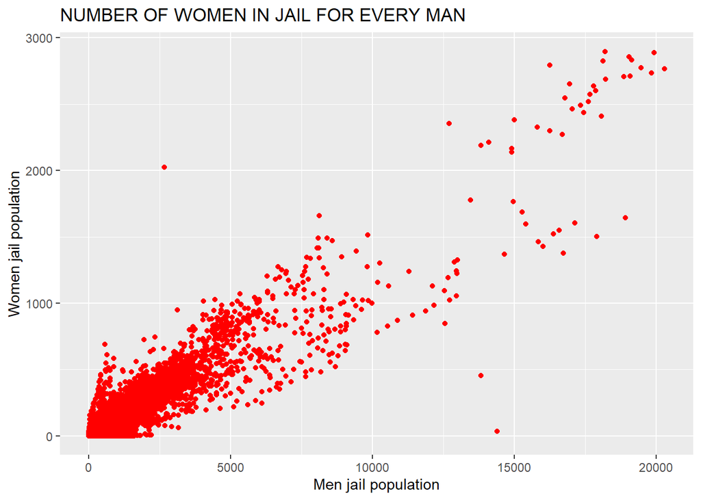

This scatter plot chart I made was to show a comparison of men in jail to women in jail using all the data. From the scatter plot, we can see that the population of men in jail is well over the population of women by about a huge 17,000 people. For some points, the women population barely get to 1,000 people as the men get close to 15,000. We can make an assumption that this is cause by toxic masculinity and the idea that a man might get a more harsh charge in some situations than a women would.

### Map

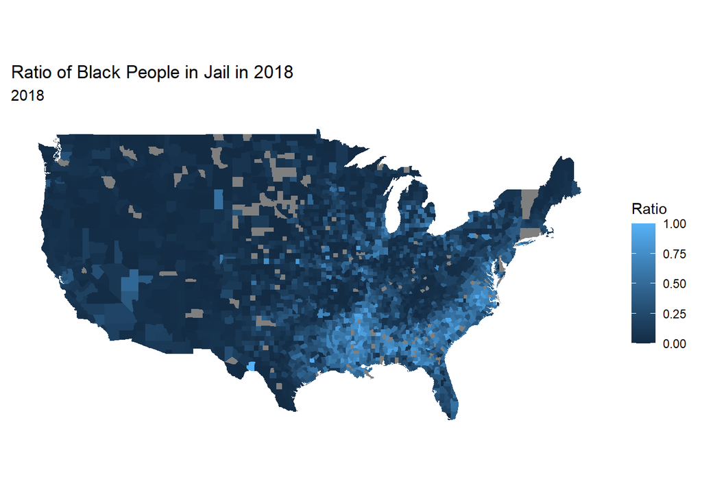

This map is a map that shows every county and state in the United States and is showing a ratio between black people in jail and a the total population of people in jail. With this map, we start to notice that the map starts to light up the closer we get to the south of the U.S. This could be due to the large amount of racism and oppression that takes place there.